# Machine Learning for Time Series Analysis: Predicting Seattle Electricity Usage

## Joseph E. McEwen, 2018

This notebook explores the use of neural networks to predict the average daily electricity consumption (referred to as the load) for the city of Seattle. The electricity consumption data (load data) is publicily available at the [U.S. Energy Information Administration](https://www.eia.gov/opendata/) (EIA). The consumption data is a time series sampled at an hourly rate. Typical time series analysis use lagged values to model the pattern in time. These auto regression type models are successful for short-term predictions. However, the focus of this project is to explore predictions based on features other than previuos values in the time series, i.e. to make models that are not akin to autoregression models. The predictions are based off of weather features, e.g., temperature and precipitation, and type of day features, such as the day of week, if the day is a holiday, if the day is apart of a three-day weekend. A model like this has the chance for attaining long-term predictions based off of weather prediction models.

**Note** : My intentions for this notebook were not to find the best model. As a first step for this project, I wanted to see what models I could build. Also, I have my doubts as to the effectiveness of using recurrent neural networks for this type of time series.

This notebook is organized as follows:

- Importing and clearning the EIA data, will fix errors in the EIA data, sample the data on a daily basis (from a hourly time frame)
- Adding temperature, day of week, and holidays as features, weather data will be scrapped from Weather Underground, daily features can be added manually
- Using neural networks to predict electricity demand, will explore variations on neural network predictions, including recurrent neural networks (specifically [long short term memory](https://en.wikipedia.org/wiki/Long_short-term_memory) (LSTM) models:
  - model 1.1 a standard feed-forward neural networwk using lagged consumption values as features
  - model 2.1 a feed-forward neural network based on lagged weather and calendar features
  - model 2.2 looping through batch size and tracking loss through epochs
  - model 3.1 a recurrent neural network with one LSTM layer
  - model 3.2 a stacked LSTM neural network
  - model 3.3 a stateful LSTM network
  - model 3.4 a stateful LSTM network with time series inputs

Web references:

- [understanding LSTMs](http://colah.github.io/posts/2015-08-Understanding-LSTMs/)
- [Unreasonable effectiveness of Recurrent Neural Networks](http://karpathy.github.io/2015/05/21/rnn-effectiveness/)
- [explanation of stateful versus stateless in Keras](http://philipperemy.github.io/keras-stateful-lstm/)
- [guide to sequential modeling in Keras](https://keras.io/getting-started/sequential-model-guide/)

Academic references:

- [Applying LSTM to Time Series Predictable through Time-Window Approaches](https://link.springer.com/chapter/10.1007/3-540-44668-0_93)
- [Recurrent Neural Network Regularization](https://arxiv.org/pdf/1409.2329.pdf)
- [A Theoretically Grounded Application of Dropout in Recurrent Neural Networks](https://arxiv.org/pdf/1512.05287.pdf)
- [Generating Sequences With Recurrent Neural Networks](https://arxiv.org/pdf/1308.0850.pdf)

```python
# import external libraries needed for data manipulation
import numpy as np
import pandas as pd
%matplotlib inline
import matplotlib.pyplot as plt
import plotly.offline as py
import plotly.graph_objs as go
from plotly import tools
from datetime import datetime
from pandas.tseries.holiday import USFederalHolidayCalendar as calendar
py.init_notebook_mode(connected=False) # to use offline in notebook
```

## Cleaning the electricity consumption data

The data was downloaded from the EIA website and stored locally as load_scl_jan2018pull.csv The data is a time series, with values for the day and hour and the amount of mega Watt hours (MWh) consumed.

```python
# read data into a dataframe
df=pd.read_csv("load_scl_jan2018pull.csv", names=["time", "MWh"])
print("the shape of the data frame is", df.shape)
df.head()
```

```
the shape of the data frame is (22471, 2)
```

|  | time | MWh |
| --- | --- | --- |
| 0 | 01/22/2018 16H | 1519.0 |
| 1 | 01/22/2018 15H | 1386.0 |
| 2 | 01/22/2018 14H | 1195.0 |
| 3 | 01/22/2018 13H | 1057.0 |
| 4 | 01/22/2018 12H | 1004.0 |

### Cleaning the data

- first take a look at the data
- remove or replace any null values or data that was likely entered incorrectly

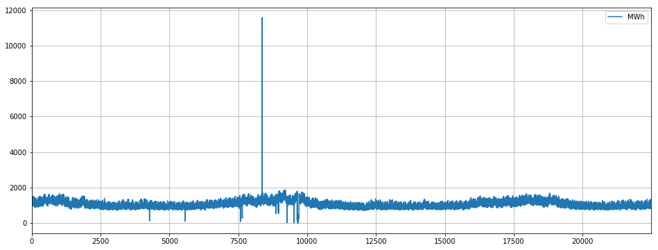

```python
df.plot(grid=True, figsize=(16,6))
```

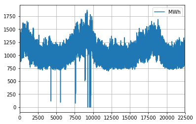

```python
id=df["MWh"].idxmax()
df["MWh"].iloc[id]=1583 # I think an extra 1 was inserted, dropping that 1
# plot to make sure it looks good
df.plot(grid=True)
```

```python
# replace the spikes below the band with the average formed by the neighboring points
for i in range(df.shape[0]):

    if df["MWh"].iloc[i] < 700:
        #df["MWh"].loc[i]=.5*(df["MWh"].loc[i+1]+df["MWh"].loc[i-1])
        df["MWh"].iloc[i]=1000+ df["MWh"].iloc[i]
```

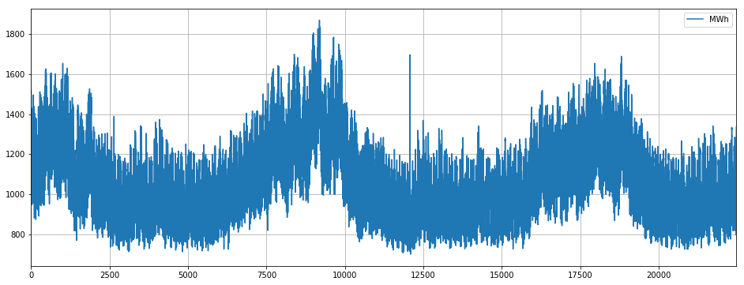

```python
# plot the cleaned data
df.plot(grid=True,figsize=(16,6))
```

### Resampling the data from hourly to daily

The data repoted by the EIA is sampled hourly. I would like a more coarse grained sampling. Pandas provides a method to resample a time series.

```python
# change date to datetime type
df["time"]=pd.to_datetime(df["time"])

# add day of week, will be used later
df["weekday"] = df["time"].dt.dayofweek

# change time to the index
df.index=df["time"]
del df["time"]
df.head()
```

| time | MWh | weekday |
| --- | --- | --- |
| 2018-01-22 16:00:00 | 1519.0 | 0 |
| 2018-01-22 15:00:00 | 1386.0 | 0 |
| 2018-01-22 14:00:00 | 1195.0 | 0 |
| 2018-01-22 13:00:00 | 1057.0 | 0 |
| 2018-01-22 12:00:00 | 1004.0 | 0 |

```python
# script to resample the data to dailyvalues
def get_daily(DF,start,end):
    # return a data frame with monthly statitistics

    df=DF[datetime(end,1,1):datetime(start,1,1)]
    sampled=pd.DataFrame()

    sampled["average MWh"]=df.MWh.resample("D").mean()
    sampled["median MWh"]=df.MWh.resample("D").median()
    sampled["total MWh"]=df.MWh.resample("D").sum()
    sampled["day"]=df.weekday.resample("D").mean()

    index=np.arange(sampled.shape[0])
    sampled["date"]=np.nan
    for i in range(sampled.shape[0]):
        sampled.date.iloc[i]=sampled.index[i]

    return sampled
```

```python
data=get_daily(df,2014,2018)
data.head()
```

| time | average MWh | median MWh | total MWh | day | date |
| --- | --- | --- | --- | --- | --- |
| 2015-07-01 | 1091.333333 | 1148.5 | 26192.0 | 2 | 2015-07-01 00:00:00 |
| 2015-07-02 | 1104.666667 | 1160.5 | 26512.0 | 3 | 2015-07-02 00:00:00 |
| 2015-07-03 | 1078.000000 | 1127.0 | 25872.0 | 4 | 2015-07-03 00:00:00 |
| 2015-07-04 | 1040.125000 | 1091.5 | 24963.0 | 5 | 2015-07-04 00:00:00 |
| 2015-07-05 | 996.375000 | 1028.0 | 23913.0 | 6 | 2015-07-05 00:00:00 |

## Adding more features

The electricty demand is determined by the idvidual activities of electricity customers in Seattle. The individual habits are determined by a variety of influences. Some of the easy ones to list are the day of week and holidays. The biggest influence is temeprature. Pandas has the ability to add days of the week information. To get temperature I will scrape [Weather Underground](https://www.wunderground.com/).

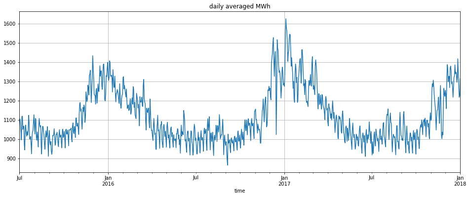

```python
data["average MWh"].plot(grid=True,figsize=(16,6), title="daily averaged MWh")
```

### Holiday feature

Pandas can get holiday dates for me. (One thing to be aware of is if the holiday falls on a weekend, it is going to be reported as occuring on a Friday or Monday.)

```python
# add holiday feature
cal=calendar()
holidays=cal.holidays(start=data.index.min(), end=data.index.max())
data["holiday"]=data.index.isin(holidays)
data.head()
```

| time | average MWh | median MWh | total MWh | day | date | holiday |
| --- | --- | --- | --- | --- | --- | --- |
| 2015-07-01 | 1091.333333 | 1148.5 | 26192.0 | 2 | 2015-07-01 00:00:00 | False |
| 2015-07-02 | 1104.666667 | 1160.5 | 26512.0 | 3 | 2015-07-02 00:00:00 | False |
| 2015-07-03 | 1078.000000 | 1127.0 | 25872.0 | 4 | 2015-07-03 00:00:00 | True |
| 2015-07-04 | 1040.125000 | 1091.5 | 24963.0 | 5 | 2015-07-04 00:00:00 | False |
| 2015-07-05 | 996.375000 | 1028.0 | 23913.0 | 6 | 2015-07-05 00:00:00 | False |

```python
# check holidays
# hol=data[data["holiday"]==True]
# hol.head(10)
```

```python
# holidays are defined as work holidays.
# If the actual holiday falls on the weekend, the holiday is often given on the Friday or Monday.
holidays
```

```
DatetimeIndex(['2015-07-03', '2015-09-07', '2015-10-12', '2015-11-11',
               '2015-11-26', '2015-12-25', '2016-01-01', '2016-01-18',
               '2016-02-15', '2016-05-30', '2016-07-04', '2016-09-05',
               '2016-10-10', '2016-11-11', '2016-11-24', '2016-12-26',
               '2017-01-02', '2017-01-16', '2017-02-20', '2017-05-29',
               '2017-07-04', '2017-09-04', '2017-10-09', '2017-11-10',
               '2017-11-23', '2017-12-25', '2018-01-01'],
              dtype='datetime64[ns]', freq=None)
```

### Adding three day weekends

Usage patterns change when a holiday leads to a three day weekend. This feature is added below.

```python
# add 3-day weekend feature
thday=[False]*data.shape[0]

# excluding the first and last indices
for i in range(0,data.shape[0]):
    if data["holiday"].iloc[i]==True:

        # on a Monday
        if data["day"].iloc[i]==0:
            thday[i]=True
            if i > 1:
                thday[i-1]=True
            if i > 2:
                thday[i-2]=True
        # on a Friday
        if data["day"].iloc[i]==4:
            thday[i]=True

            if i < data.shape[0]-1:
                thday[i+1]=True
            if i < data.shape[0]-2:
                thday[i+2]=True

data["3-day wkend"]=thday
data.head()
```

| time | average MWh | median MWh | total MWh | day | date | holiday | 3-day wkend |
| --- | --- | --- | --- | --- | --- | --- | --- |
| 2015-07-01 | 1091.333333 | 1148.5 | 26192.0 | 2 | 2015-07-01 00:00:00 | False | False |
| 2015-07-02 | 1104.666667 | 1160.5 | 26512.0 | 3 | 2015-07-02 00:00:00 | False | False |
| 2015-07-03 | 1078.000000 | 1127.0 | 25872.0 | 4 | 2015-07-03 00:00:00 | True | True |
| 2015-07-04 | 1040.125000 | 1091.5 | 24963.0 | 5 | 2015-07-04 00:00:00 | False | True |
| 2015-07-05 | 996.375000 | 1028.0 | 23913.0 | 6 | 2015-07-05 00:00:00 | False | True |

### Getting weather information from weather underground

Temperature and percipitation data are scrapped from weather underground using BeautifulSoup.

```python
# import needed external libraries
import urllib3
import requests
from bs4 import BeautifulSoup as bs
```

```python
def get_weather_info(datestamp, loc):
    x=datestamp.to_pydatetime()
    date=str(x.year)+"/"+str(x.month)+"/"+str(x.day)
    #print(date)

    url="https://www.wunderground.com/history/airport/"+loc+"/"+date+"/DailyHistory.html"
    #print(url)

    page=requests.get(url)
    soup=bs(page.content, "html.parser")


    historytable=soup.find('table',id='historyTable')
    spans=historytable.find_all(attrs={'class':'wx-data'})
    t_mean=spans[0].span.string
    t_max=spans[3].span.string
    t_min=spans[6].span.string
    precip=spans[8].span.string


    return t_mean,t_max,t_min, precip
```

```python
# locations
# KBFI : Boeing field
# KSEA : Airport

# test scrapper
get_weather_info(data["date"].iloc[0], "KBFI")
```

```python
# gather weather data
# mark location when bad data was collected

weather=np.zeros((data.shape[0],4))
for i in range(data.shape[0]):
    weather[i,:]=get_weather_info(data["date"].iloc[i], "KBFI")
    if weather[i,3]>2:
        print("bad value at ", i)
```

```python
# fix bad values manually (after looking them up)
weather[228,3]=0.0
weather[243,3]=0.12
```

```python
data["mean temp"]=weather[:,0]
data["max temp"]=weather[:,1]
data["min temp"]=weather[:,2]
data["precipitation"]=weather[:,3]
data["delta temp"]=data["max temp"].values - data["min temp"].values
data.head()
```

It takes some time to get the weather information. It is better to save the data and reload.

```python
# save this data to a csv file for future use
#data.to_csv("usage_plus_features.csv")

# read in data
data=pd.read_csv("usage_plus_features.csv")

# change time to the index
data.index=data["time"]
del data["time"]
data.head()
```

| time | average MWh | median MWh | total MWh | day | date | holiday | 3-day wkend | mean temp | max temp | min temp | precipitation | delta temp |
| --- | --- | --- | --- | --- | --- | --- | --- | --- | --- | --- | --- | --- |
| 2015-07-01 | 1091.333333 | 1148.5 | 26192.0 | 2 | 2015-07-01 00:00:00 | False | False | 76.0 | 91.0 | 45.0 | 0.0 | 46.0 |
| 2015-07-02 | 1104.666667 | 1160.5 | 26512.0 | 3 | 2015-07-02 00:00:00 | False | False | 80.0 | 92.0 | 43.0 | 0.0 | 49.0 |
| 2015-07-03 | 1078.000000 | 1127.0 | 25872.0 | 4 | 2015-07-03 00:00:00 | True | True | 80.0 | 93.0 | 44.0 | 0.0 | 49.0 |
| 2015-07-04 | 1040.125000 | 1091.5 | 24963.0 | 5 | 2015-07-04 00:00:00 | False | True | 77.0 | 91.0 | 43.0 | 0.0 | 48.0 |
| 2015-07-05 | 996.375000 | 1028.0 | 23913.0 | 6 | 2015-07-05 00:00:00 | False | True | 78.0 | 91.0 | 47.0 | 0.0 | 44.0 |

### Adding black Friday

For many people Thanksgiving is actually a 4-day weekend. I will add black Friday to account for this.

```python
# locate black Friday dates
print(np.where(data.index=="2017-11-24")[0])
print(np.where(data.index=="2016-11-25")[0])
print(np.where(data.index=="2015-11-27")[0])
```

```
[877]
[513]
[149]
```

```python
data["holiday"].iloc[877]=True
data["3-day wkend"].iloc[877]=True
data["holiday"].iloc[513]=True
data["3-day wkend"].iloc[513]=True
data["holiday"].iloc[149]=True
data["3-day wkend"].iloc[149]=True
data.head()
```

| time | average MWh | median MWh | total MWh | day | date | holiday | 3-day wkend | mean temp | max temp | min temp | precipitation | delta temp |
| --- | --- | --- | --- | --- | --- | --- | --- | --- | --- | --- | --- | --- |
| 2015-07-01 | 1091.333333 | 1148.5 | 26192.0 | 2 | 2015-07-01 00:00:00 | False | False | 76.0 | 91.0 | 45.0 | 0.0 | 46.0 |
| 2015-07-02 | 1104.666667 | 1160.5 | 26512.0 | 3 | 2015-07-02 00:00:00 | False | False | 80.0 | 92.0 | 43.0 | 0.0 | 49.0 |
| 2015-07-03 | 1078.000000 | 1127.0 | 25872.0 | 4 | 2015-07-03 00:00:00 | True | True | 80.0 | 93.0 | 44.0 | 0.0 | 49.0 |
| 2015-07-04 | 1040.125000 | 1091.5 | 24963.0 | 5 | 2015-07-04 00:00:00 | False | True | 77.0 | 91.0 | 43.0 | 0.0 | 48.0 |
| 2015-07-05 | 996.375000 | 1028.0 | 23913.0 | 6 | 2015-07-05 00:00:00 | False | True | 78.0 | 91.0 | 47.0 | 0.0 | 44.0 |

```python
#plot to check temperature
fig=plt.figure(figsize=(16,8))

t1 = go.Scatter(x=data.index, y=data["mean temp"].values, name= "mean temperature")
t2 = go.Scatter(x=data.index, y=data["max temp"].values, name= "maximum temperature")
t3 = go.Scatter(x=data.index, y=data["min temp"].values, name= "minimum temperature")

#py.offline.plot([t1,t2,t3], filename='temp_plot.html')
py.iplot([t1,t2,t3])
#py.offline.plot([t1,t2,t3], output_type="div")
```

[interactive chart not shown]

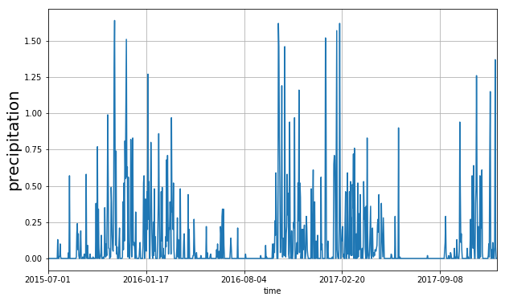

```python
fig=plt.figure(figsize=(10,6))

ax=fig.add_subplot(111)
ax.set_ylabel("precipitation",size=20)
data["precipitation"].plot(grid=True)
```

## Machine learning forecasting

```python
# import keras and sklearn libraries
from keras.models import Sequential
from keras.layers import Dense
from keras.layers import LSTM
from keras.layers import Dropout
from keras import regularizers
from keras import callbacks
from keras.callbacks import EarlyStopping
from sklearn.preprocessing import MinMaxScaler
from sklearn.metrics import mean_squared_error
from sklearn.metrics import log_loss

# set seed for reproducibility
#from tensorflow import set_random_seed
#set_random_seed(42) # the year TOSU won their first national championship
```

The data features need to be formated for time series analysis with a neural networks. There are two types of data formats that I will be using:

- The first is a lagged window format. In this format lagged features are included as columns in the feature matrix. For example the feature matrix columns may include: temperature 3-days ago, temperature 2-days ago, temperature 1-day ago, the current value of temperature. This format is obtained by a call to the **get_ANN_data** function. The returned data is suitable for a feed-forward neural network. However, you can set the optional variable **lstm_shape=True** to return a format suitable for LSTM units.
- The other format puts features as a list of time series data. For example, one column may hold the array of [temperature 3-days ago, temperature 2-days ago, temperature 1-day ago, the current value of temperature]. This format is obtained by a call to the **get_RNN_data** function and is only suitable for LSTM units.

The funtions below prep the data for the two data formats above. Below is also a function **output_analysis** that plots the predicted and true values and prints the mean square error.

```python
def time_series_to_ANN(data,lagged_names,names,lag=1,window_size=None,dropnan=True):
    # function to take multivariate time series dataframe
    # and convert it into a data frame with columns composed of
    # the desired lagged values

    cols, df_names=list(), list()

    if window_size is None:
    # lagged sequence (t-n, ..., t-1)
        for i in range(lag,0,-1):

            # shift columns (downward in the dataframe by i)
            cols.append(data[lagged_names].shift(i))

            # add names for lagged columns
            df_names+=[ name + " (t-%d)" %i for name in lagged_names]

    else:
    # lagged sequence
        for i in range(lag,lag-window_size,-1):

            # shift columns (downward in the dataframe by i)
            cols.append(data[lagged_names].shift(i))

            # add names for lagged columns
            df_names+=[ name + " (t-%d)" %i for name in lagged_names]

    # current data
    df_names+=[ name + " (t)" for name in names]
    cols.append(data[names])

    # combinde together
    df=pd.concat(cols,axis=1)
    df.columns=df_names

    if dropnan:
        df.dropna(inplace=True)
    return df
```

```python
def time_series_to_RNN(data,lagged_names,lag=1,dropnan=True):
    # function to take multivariate time series dataframe
    # and convert it into a data frame with columns composed of
    # lists of lagged time series data

    target_name=["average MWh"]

    cols, df_names=list(), list()

    # lagged sequence (t-n, ..., t-1)
    for i in range(lag,-1,-1):

        # shift columns (downward in the dataframe by i)
        cols.append(data[lagged_names].shift(i))

        # add names for lagged columns
        df_names+=[ name + " (t-%d)" %i for name in lagged_names]

    # current data
    df_names+=target_name
    cols.append(data[target_name])

    # combinde together
    df=pd.concat(cols,axis=1)
    df.columns=df_names

    if dropnan:
        df.dropna(inplace=True)
    return df
```

```python
def prep_data_ANN(data,target_name,train_size=.67,lstm_shape=False):
    # scales data and splits into
    # training and testing sets

    time=data.index.values

    split=int(data.shape[0]*train_size)

    names=data.columns.values

    pred_names=list(set(names)-set(target_name))

    # scale transformations for the predictors and targets
    scaler_X=MinMaxScaler(feature_range=(0,1))
    scaler_y=MinMaxScaler(feature_range=(0,1))

    scaler_X.fit(data[pred_names])
    scaler_y.fit(data[target_name])

    data_X=scaler_X.fit_transform(data[pred_names])
    data_y=scaler_y.fit_transform(data[target_name])

    train_X=data_X[:split,:]
    train_y=data_y[:split]

    test_X=data_X[split:,:]
    test_y=data_y[split:,:]


    # change shape for Keras lstm input (number of samples, 1 times step, features)
    if lstm_shape:
        train_X=np.reshape(train_X,(train_X.shape[0],1,train_X.shape[1]))
        test_X=np.reshape(test_X,(test_X.shape[0],1,test_X.shape[1]))

    time_train=time[:split]
    time_test=time[split:]

    return train_X,train_y, test_X, test_y, time_train, time_test, scaler_y
```

```python
def prep_data_RNN(data,target_name,shapes,train_size=.67):
    # scales data and splits into
    # training and testing sets

    time_steps,n_features=shapes
    n_lags=int(time_steps*n_features)

    time=data.index.values

    split=int(data.shape[0]*train_size)

    names=data.columns.values

    # predict names is all the names up to the last column
    pred_names=names[:-1]

    # scale transformations for the predictors and targets
    scaler_X=MinMaxScaler(feature_range=(0,1))
    scaler_y=MinMaxScaler(feature_range=(0,1))

    scaler_X.fit(data[pred_names])
    scaler_y.fit(data[target_name])

    data_X=scaler_X.fit_transform(data[pred_names])
    data_y=scaler_y.fit_transform(data[target_name])

    train_XX=data_X[:split,:]
    train_y=data_y[:split]

    test_XX=data_X[split:,:]
    test_y=data_y[split:,:]


    # change shape for Keras input
    train_X=np.zeros((train_XX.shape[0],time_steps,n_features))
    test_X=np.zeros((test_XX.shape[0],time_steps,n_features))


    # loop through samples
    for i in range(train_X.shape[0]):

        ids=np.arange(0,n_lags,n_features)

        # loop through features
        for f in range(n_features):

            train_X[i,:,f]=train_XX[i,ids]
            ids=ids+1

    # loop through samples
    for i in range(test_X.shape[0]):

        ids=np.arange(0,n_lags,n_features)

        # loop through features
        for f in range(n_features):

            test_X[i,:,f]=test_XX[i,ids]
            ids=ids+1

    time_train=time[:split]
    time_test=time[split:]

    return train_X,train_y, test_X, test_y, time_train, time_test, scaler_y
```

```python
def get_ANN_data(data,lagged_names,names,lag=1,window_size=None,lstm_shape=False):

    X=time_series_to_ANN(data,lagged_names,names,lag=lag,window_size=window_size)

    train_X,train_y,test_X,test_y,time_train, time_test, scaler_y=prep_data_ANN(X,["average MWh (t)"],lstm_shape=lstm_shape)

    return train_X,train_y, test_X, test_y, time_train, time_test, scaler_y
```

```python
def get_RNN_data(data,lagged_names,lag=1):

    n_features=len(lagged_names)

    time_steps=lag+1

    shapes=(time_steps,n_features)

    X=time_series_to_RNN(data,lagged_names,lag=lag)

    train_X,train_y,test_X,test_y,time_train, time_test, scaler_y=prep_data_RNN(X,["average MWh"],shapes)

    return train_X,train_y, test_X, test_y, time_train, time_test, scaler_y
```

```python
def output_analysis(train_X, train_y, test_X, test_y,model,scaler,time_test,batchsize=None, plot=True):

    if batchsize is not None:
        train_pred=model.predict(train_X,batch_size=batchsize)
        test_pred=model.predict(test_X,batch_size=batchsize)
    else:

        train_pred=model.predict(train_X)
        test_pred=model.predict(test_X)

    train_pred=scaler.inverse_transform(train_pred)
    train_y=scaler.inverse_transform(train_y)

    test_pred=scaler.inverse_transform(test_pred)
    test_y=scaler.inverse_transform(test_y)

    train_score=np.sqrt(mean_squared_error(train_y,train_pred))
    test_score=np.sqrt(mean_squared_error(test_y,test_pred))
    print("mean squared error for the training and testing data are:", train_score,test_score)

    time_test=[datetime.strptime(t,'%Y-%m-%d') for t in time_test]

    if plot:
        layout=go.Layout(
        yaxis=dict(title="daily mean usage [MWh]"))

        y=test_pred[:,0]
        p1 = go.Scatter(x=time_test,y=y,name="predicted")
        y=test_y[:,0]
        p2 = go.Scatter(x=time_test,y=y,name="true")

        fig=go.Figure(data=[p1,p2],layout=layout)
        py.iplot(fig)

    return train_y, train_pred, test_y, test_pred
```

### model 1.1

```python
lagged_names=["average MWh"]
names=["average MWh"]
train_X,train_y,test_X,test_y,time_train, time_test, scaler_y=get_ANN_data(data,lagged_names,names,lag=2)

model=Sequential()

epochs=50
batch_size=10

# a neural network with 2 hidden layers, with neurons 10 and 5, and an output layer of neurons 1
# make sure to understand input_dim
model.add(Dense(10,input_dim=train_X.shape[1],activation="relu"))
model.add(Dense(5, activation="relu"))
model.add(Dense(1))
model.compile(loss="mean_squared_error",optimizer="adam")

# fit the neural network
# verbose = 0 is for no vebose
model.fit(train_X,train_y,epochs=epochs,batch_size=batch_size,verbose=0)

# analysis
_,_, test_y, test_pred= output_analysis(train_X, train_y, test_X, test_y, model,scaler_y,time_test)
```

```
mean squared error for the training and testing data are: 53.7639881783 49.1736913835
```

[interactive chart not shown]

### model 2.1

A model based on the previus days demand is not very impressive. In the next model, I will exclude all features based on consumption and only use weather related and day related features.

```python
# lagged (1 day) or weather features
lagged_names=["mean temp", "max temp","min temp","precipitation"]
names=["average MWh","day","holiday","3-day wkend","mean temp","max temp","min temp","precipitation"]

train_X,train_y,test_X,test_y,time_train, time_test, scaler_y=get_ANN_data(data,lagged_names,names)

model=Sequential()
# train for 50 epochs
epochs=50

# a neural network with 2 hidden layers, with neurons 10 and 5, and an output layer of neurons 1

# make sure to understand input_dim
model.add(Dense(10,input_dim=train_X.shape[1],activation="relu"))
model.add(Dense(5, activation="relu"))
model.add(Dense(1))
model.compile(loss="mean_squared_error",optimizer="adam")
#mdel.summary()

model.fit(train_X,train_y,epochs=epochs,batch_size=5,verbose=0)

# anlysis
_,_, test_y, test_pred= output_analysis(train_X, train_y, test_X, test_y, model,scaler_y,time_test)
```

```
mean squared error for the training and testing data are: 36.8483806061 40.1159807582
```

[interactive chart not shown]

Model 2.1 appears to be comparable to model 1.1. That is promising, as it means that a forecasting model could potentially be built soley as a function of weather variables with a neural network.

### Adding in a callback for loss function evalutions at the end of each epoch

To track the progress of the nueral network fitting, keras provides a callback functionality to do that. The functions defined below untilize this callback feature to collect the history of loss function evaluations through training epochs. I also created a function called TwoLayerANN that allows me to call a two-layered neural network. This was specifically designed so I could loop through neural network parameters. I will use this to look at the effect of changing batch size on the loss function history, tracking both the training and test history.

### model 2.2

```python
# see here https://keras.io/callbacks/ keras callbacks (specifically what logs tracks)
class LossHistory(callbacks.Callback):
    def on_train_begin(self, logs={}):
        self.train_losses = []
        self.val_losses=[]
        #self.train_acc = []
        #self.val_acc=[]

    def on_epoch_end(self, batch, logs={}):
        self.train_losses.append(logs.get('loss'))
        self.val_losses.append(logs.get("val_loss"))
        #self.train_acc.append(logs.get('acc'))
        #self.val_acc.append(logs.get("val_acc"))
```

```python
def TwoLayerANN(train_X,train_y,test_X,test_y,size,activations,batch_size,epochs,loss,dropout=0.0):

    from tensorflow import set_random_seed
    set_random_seed(2)

    model=Sequential()

    if dropout==0.0:

        model.add(Dense(size[0],input_dim=train_X.shape[1],activation=activations[0]))
        model.add(Dense(size[1], activation=activations[1]))
        model.add(Dense(1,activation=activations[2]))
        model.compile(loss=loss,optimizer="adam", metrics=["acc"])

    else:
        # I tried a model with dropout, but these results were just terrible
        model.add(Dropout(dropout,input_shape=(train_X.shape[1],)))
        model.add(Dense(size[0],activation=activations[0]))
        #model.add(Dropout(dropout))
        model.add(Dense(size[1], activation=activations[1]))
        #model.add(Dropout(dropout))
        model.add(Dense(1,activation=activations[2]))
        model.compile(loss=loss,optimizer="adam", metrics=["acc"])


    hist=LossHistory()

    model.fit(train_X,train_y,validation_data=(test_X,test_y),epochs=epochs,batch_size=batch_size,verbose=0,
              callbacks=[hist])

    return model, hist
```

```python
lagged_names=["mean temp", "max temp","min temp","precipitation"]
names=["average MWh","day","holiday","3-day wkend","mean temp","max temp","min temp","precipitation"]

train_X,train_y,test_X,test_y,time_train, time_test, scaler_y=get_ANN_data(data,lagged_names,names)

size=(10,6)
activations=("relu","relu","sigmoid")
batch_size=np.arange(1,21,2)
epochs=20
loss="mean_squared_error"

hist=[]
for bs in batch_size:

    model,h=TwoLayerANN(train_X,train_y,test_X,test_y,size,activations,bs,epochs,loss)
    hist.append(h)
```

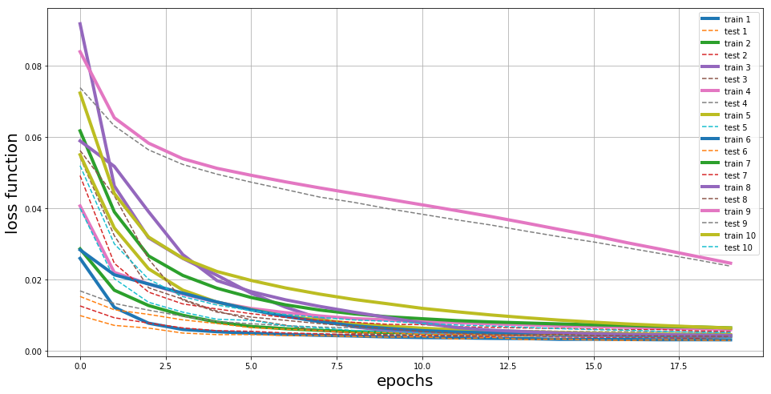

```python
fig=plt.figure(figsize=(16,8))
ax=fig.add_subplot(111)
ax.set_xlabel("epochs", size=20)
ax.set_ylabel("loss function", size=20)
ax.grid()
epochs=np.arange(20)

i=1
for h in hist:
    x1=h.train_losses
    x2=h.val_losses

    l1="train "+str(i)
    l2="test "+str(i)
    ax.plot(epochs,x1,lw=4,label=l1)
    ax.plot(epochs,x2,"--",label=l2)
    i+=1
ax.legend()
```

### model 2.3

I will try a model with multiple hidden layers and much longer number of epochs.

```python
# multiple hidden layes run for many epochs

# lagged (1 day) for weather features
lagged_names=["mean temp", "max temp","min temp","precipitation"]
names=["average MWh","day","holiday","3-day wkend","mean temp","max temp","min temp","precipitation"]

train_X,train_y,test_X,test_y,time_train, time_test, scaler_y=get_ANN_data(data,lagged_names,names)


model=Sequential()


# train for 500 epochs
epochs=500

# make sure to understand input_dim
model.add(Dense(10,input_dim=train_X.shape[1],activation="relu"))
model.add(Dense(8, activation="relu"))
model.add(Dense(6, activation="relu"))
model.add(Dense(4, activation="relu"))
model.add(Dense(1,activation="sigmoid"))
model.compile(loss="mean_squared_error",optimizer="adam")

model.fit(train_X,train_y,epochs=epochs,batch_size=5,verbose=0)

# anlysis
_,_, test_y, test_pred= output_analysis(train_X, train_y, test_X, test_y, model,scaler_y,time_test)
```

```
mean squared error for the training and testing data are: 39.5648388074 42.8995068762
```

[interactive chart not shown]

## Recurrent neural networks

The models presented so far are standard multi-layer-perceptron (MLP) neural networks. MLPs can only map input to output. A recurrent neural network (RNN), on the other hand, allows for cyclic connections that can map histories to output. This is accomplished by feeding in both the input information and output from the previous state to a neuron (there is a cyclic connection between output and input).

## The LSTM memory

The RNNs in this notebook make use of [long short-term memory (LSTM)](https://en.wikipedia.org/wiki/Long_short-term_memory) units. LSTM units are able store, write, and read information during training. This type of memory manipulation is controlled by three gates: the input gate, the forget gate, and the output gate.

Gating is controlled by a sigmoid function. A sigmoid function is a continous function between 0 and 1. When the sigmoid returns 0 the gate is fully closed, when it returns 1 the gate is fully open. The gate passes intermediate information when the sigmoid returns a value between 0 and 1.

An example of a LSTM unit is as follows:

- A linear combination of the input feature $x_t$ (at time $t$) and the output $h_{t-1}$ (at time $t-1$) is feed into a sigmoid function. This value is stored as the input gate $i_t$ (at time $t$). \begin{equation} i_t=\sigma( W_{xi}x_t + W_{hi} h_{t-1} + b_i ) \tag{2.1.1} \end{equation}
- The forget gate $f_t$ (at time $t$) is stored as a sigmoid activation of the $x_t$ and $h_{t-1}$. \begin{equation} f_t=\sigma(W_{xf} x_t + W_{hf} h_{t-1} + b_f) \tag{2.1.2} \end{equation}
- The output gate is a sigmoid activated linear combination of $x_t$, $h_{t-1}$ and $c_{t-1}$. \begin{equation} o_t=\sigma(W_{xo} x_t + W_{ho} h_{t-1} + W_{co} c_t + b_o) \tag{2.1.3} \end{equation}
- A sigmoid activted linear combination of $x_t$ and $h_{t-1}$ is stored as $g_t$. \begin{equation} g_t=\sigma(W_{xg}x_t + W_{hg}h_{t-1} + b_g) \tag{2.1.4} \end{equation}
- Memory is updated by multiplying the forget gate with the previous memory ($c_{t-1}$) and adding the multiplication of the input gate with $g_t$. \begin{equation} c_t=f_tc_{t-1} + i_t g_t \tag{2.1.5} \end{equation}
- The output is controlled by a multiplication of the output gate with a sigmoid activated $c_t$. \begin{equation} h_t=o_t \sigma(c_t) \tag{2.1.6} \end{equation}

### model 3.1

A LSTM RNN with a lag of 7 days.

```python
# true RNN model
lagged_names=["day","holiday","3-day wkend","mean temp","max temp","min temp","precipitation"]

train_X,train_y,test_X,test_y,time_train, time_test, scaler_y=get_RNN_data(data,lagged_names,lag=7)
train_X.shape

model=Sequential()

lstm_smart_units=10
epochs=100

# shape should be number of time steps, number of features
input_shape=(train_X.shape[1],train_X.shape[2])
#input_shape=(1,lag)

print(train_X.shape, test_X.shape)
model.add(LSTM(lstm_smart_units, input_shape=input_shape))
model.add(Dense(1,activation="sigmoid"))
model.compile(loss="mean_squared_error",optimizer="adam")

model.fit(train_X,train_y,epochs=epochs,batch_size=10,verbose=0)# look at MSE and plot output
_,_, test_y, test_pred= output_analysis(train_X, train_y, test_X, test_y, model,scaler_y,time_test)
```

```
(609, 8, 7) (300, 8, 7)
mean squared error for the training and testing data are: 36.6430877069 44.492549154
```

[interactive chart not shown]

### model 3.2

```python
# stacked LSTMs

# true RNN model
lagged_names=["day","holiday","3-day wkend","mean temp","max temp","min temp","precipitation"]

train_X,train_y,test_X,test_y,time_train, time_test, scaler_y=get_RNN_data(data,lagged_names,lag=3)
train_X.shape

model=Sequential()

epochs=300

# shape should be number of time steps, number of features
input_shape=(train_X.shape[1],train_X.shape[2])

batch_size=10

# dropouts
dropout=.5
r_dropout=.05

# early stopping
earlystop = EarlyStopping(monitor='val_loss', min_delta=0.0001, patience=20,verbose=1, mode='auto')

callbacks= [earlystop]

model.add(LSTM(100, input_shape=input_shape,return_sequences=True,recurrent_dropout=dropout))
model.add(LSTM(150,return_sequences=True))
model.add(LSTM(40,return_sequences=True))
model.add(LSTM(20,return_sequences=True))
model.add(LSTM(10,return_sequences=True))
model.add(LSTM(5))

# with some arbitrary chosen dropout
#model.add(LSTM(**,return_sequences=True, dropout=dropout))
#model.add(LSTM(**,recurrent_dropout=r_dropout))

model.add(Dense(1,activation="sigmoid"))


model.compile(loss="mean_squared_error",optimizer="adam")
model.fit(train_X,train_y,epochs=epochs,validation_data=(test_X,test_y),batch_size=10,callbacks=callbacks,verbose=0)
# look at MSE and plot output
_,_, test_y, test_pred= output_analysis(train_X, train_y, test_X, test_y, model,scaler_y,time_test)
```

```
Epoch 00052: early stopping
mean squared error for the training and testing data are: 39.7027853673 45.8020425014
```

[interactive chart not shown]

### model 3.3

We can pass information between batches by running the LSTM in stateful mode. There seems to be a lot of confussion on what stateful means in Keras. Hopefully, I got this right. All LSTMs are stateful. Stateful in Keras means that the output from each batch is stored and can be passed to the next batch. In a stateless mode, long term memory is not stored between batches. To build a stateful model, I will use the time series data in the feed-forward format that is shaped for an LSTM input. I will set the batchsize =1 and fix the shuffling to False. Then I will explicitly loop through each epoch. Since the batchsize is 1, the network updates after each sample is passed. Since the network is stateful, the state from each pass is passed to the next. At the end of each epoch the state is manually reset.

```python
# adding memory between between batches with lstm neurons.

lagged_names=["mean temp","max temp","min temp","precipitation"]
names=["average MWh","day","holiday","3-day wkend","mean temp","max temp","min temp","precipitation"]

train_X,train_y,test_X,test_y,time_train, time_test, scaler_y=get_ANN_data(data,lagged_names,names,lag=3,lstm_shape=True)
train_X.shape

model=Sequential()

lstm_smart_units=10
epochs=100

batch_size=1
batch_input_shape=(batch_size,1,train_X.shape[2])

print(train_X.shape)
model.add(LSTM(lstm_smart_units, batch_input_shape=batch_input_shape,stateful=True))
model.add(Dense(1,activation="sigmoid"))
model.compile(loss="mean_squared_error",optimizer="adam")
```

```
(611, 1, 19)
```

```python
for i in range(epochs):
    model.fit(train_X,train_y,epochs=1,batch_size=batch_size,verbose=0,shuffle=False)
    model.reset_states()
```

```python
_,_, test_y, test_pred= output_analysis(train_X, train_y, test_X, test_y,model,scaler_y,time_test,batchsize=1)
```

```
mean squared error for the training and testing data are: 35.5874538687 40.1238890952
```

[interactive chart not shown]

### model 3.4

Building off the last model I will now run a stateful model in which the input features are arrays themselves.

```python
# adding memory between between batches with lstm neurons in a fully recurrent model

lagged_names=["day","holiday","3-day wkend","mean temp","max temp","min temp","precipitation"]

train_X,train_y,test_X,test_y,time_train, time_test, scaler_y=get_RNN_data(data,lagged_names,lag=3)
train_X.shape

model=Sequential()

epochs=30

# shape should be number of time steps, number of features
input_shape=(train_X.shape[1],train_X.shape[2])

batch_size=1
batch_input_shape=(batch_size,train_X.shape[1],train_X.shape[2])

print(train_X.shape)

model.add(LSTM(30, batch_input_shape=batch_input_shape,stateful=True))
model.add(Dense(1,activation="sigmoid"))
model.compile(loss="mean_squared_error",optimizer="adam")
```

```
(611, 4, 7)
```

```python
for i in range(epochs):
    model.fit(train_X,train_y,epochs=1,batch_size=batch_size,verbose=0,shuffle=False)
    model.reset_states()
```

```python
_,_, test_y, test_pred= output_analysis(train_X, train_y, test_X, test_y,model,scaler_y,time_test,batchsize=1)
```

```
mean squared error for the training and testing data are: 36.4125468145 43.2715788869
```

[interactive chart not shown]